# 04.Example 1

Modified

Su 2026-09-13 19:30

## Given:

Consider a person that has a layer of skin/fat covered with a special sporting gear suit, with the outer surface exposed to air at a temperature of $10\ \mathrm{°C}$ with a convective heat transfer coefficient of $2\ \frac{\mathrm{W}}{\left(\mathrm{K} \cdot \mathrm{m}^{2}\right)}$. The inner surface (under the layer of skin/fat) is maintained at a constant temperature of $35\ \mathrm{°C}$ through a process called [thermoregulation](https://en.wikipedia.org/wiki/Thermoregulation). The skin/fat layer has a thickness of $3\ \mathrm{mm}$ and an effective thermal conductivity of $0.3\ \frac{\mathrm{W}}{\left(\mathrm{K} \cdot \mathrm{m}\right)}$. The total surface area of the skin/fat is $1.8\ \mathrm{m}^{2}$. The special sporting gear suit has a thermal conductivity of $0.014\ \frac{\mathrm{W}}{\left(\mathrm{K} \cdot \mathrm{m}\right)}$. The emissivity of the outer surface of the special sporting gear suit is $0.95$.

## Required:

What thickness of the sporting gear suit is needed to reduce the heat loss rate to $100\ \mathrm{W}$? What is the resulting skin temperature?

## Solution:

Start first by defining all of the given values.

$$T_{\infty} = 10\ \mathrm{°C} = 283.15\ \mathrm{K}$$
$$h = 2\ \frac{\mathrm{W}}{\left(\mathrm{K} \cdot \mathrm{m}^{2}\right)}$$
$$T_i = 35\ \mathrm{°C} = 308.15\ \mathrm{K}$$
$$L_{sf} = 3\ \mathrm{mm}$$
$$k_{sf} = 0.3\ \frac{\mathrm{W}}{\left(\mathrm{K} \cdot \mathrm{m}\right)}$$
$$A = 1.8\ \mathrm{m}^{2}$$
$$k_{ins} = 0.014\ \frac{\mathrm{W}}{\left(\mathrm{K} \cdot \mathrm{m}\right)}$$
$$\varepsilon = 0.95$$
$$q = 100\ \mathrm{W}$$

Since an emissivity is given, there must be radiation occurring. The surrounding temperature may be assumed the same as the air temperature although this is not always the case. This is shown below.

$$T_{sur} = T_{\infty}$$

Other known quantities that will be used are shown below.

$$\sigma = 5.67\times 10^{-8}\ \frac{\mathrm{W}}{\left(\mathrm{K}^{4} \cdot \mathrm{m}^{2}\right)}$$

The drawing of the system is shown below.

Figure 1: System Diagram

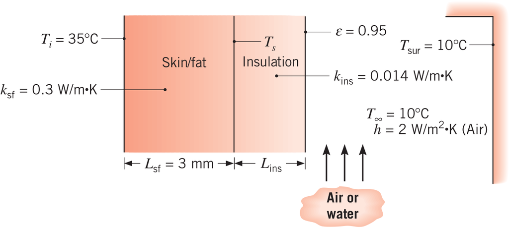

A solution may be reached by drawing the thermal circuit of the system. This is shown below.

Figure 2: Thermal Circuit

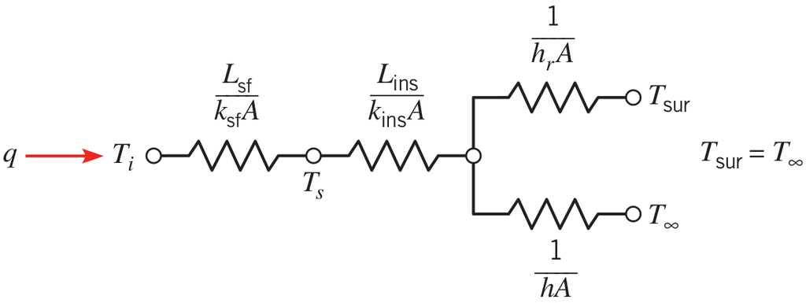

Looking at the circuit, it may be seen that the skin temperature may be found quite straightforwardly. Recognizing that the temperature drop across the skin is

$$T_i-T_s=q\frac{L_{sf}}{k_{sf}A}$$

Solving for the skin temperature is then

Answer: $T_s = T_i-q\frac{L_{sf}}{k_{sf} A} = 307.6\ \mathrm{K} = 34.4\ \mathrm{°C}$

Looking at the circuit, it may be seen that the total thermal resistance may be found by

$$R_{tot} = \frac{T_i-T_{\infty}}{q} = 0.25\ \frac{\mathrm{Δ°C}}{\mathrm{W}}$$

The total thermal resistance is also equal to

$$R_{tot}=\frac{L_{sf}}{k_{sf}A}+\frac{L_{ins}}{k_{ins}A}+\frac{1}{\frac{1}{\frac{1}{hA}}+\frac{1}{\frac{1}{h_rA}}}$$

Rearranging shows

$$R_{tot}=\frac{1}{A}\left(\frac{L_{sf}}{k_{sf}}+\frac{L_{ins}}{k_{ins}}+\frac{1}{h+h_r}\right)$$

Inspecting the expression, it may be seen that there are only two unknowns, $L_{ins}$ and $h_r$. Since $L_{ins}$ is what the problem is asking for, this is ok to be as an unknown. $h_r$ must first be determined to find $L_{ins}$. $h_r$ is defined as

$$h_r=\varepsilon\sigma\left(T_1+T_{sur}\right)\left(T_1^2+T_{sur}^2\right)$$

where $T_1$ is the temperature at the exterior surface of the special sporting gear suit. Inspecting the expression above reveals that $T_1$ is unknown. To find $T_1$, $L_{ins}$ would need to be known. Since $L_{ins}$ is unknown, an impasse is reached. To solve this method, an iterative technique must be used. Iterative technique works by first making a guess for one unknown variable and then calculating some other variable with the guess. The calculated value is used to calculate the first guessed variable value. If the guessed value and the calculated value are the same, a solution is reach. If the two values are different, another iteration of guessing must be done. This is repeated until the two numbers are the same. The iterative technique is said to have converged at this point. To begin the iterative technique for this problem, an initial guess of $T_1$ is made.

**Iteration 1**

An intelligent guess may be made for the first guess. It is reasonable to assume that $T_1$ will fall between $T_i$ and $T_{\infty}$ so the simple average of the two is used as the initial guess.

$$T_1 = \frac{T_i + T_{\infty}}{2} = 295.6\ \mathrm{K} = 22.5\ \mathrm{°C}$$

Now the radiation heat transfer coefficient may be calculated.

$$h_r = \varepsilon \sigma (T_1 + T_{sur}) (T_1^2 + T_{sur}^2) = 5.225\ \frac{\mathrm{W}}{\left(\mathrm{K} \cdot \mathrm{m}^{2}\right)}$$

$L_{ins}$ may now be found by solving the total thermal resistance expression for it. This is shown below.

$$L_{ins} = k_{ins} (A R_{tot}-\frac{L_{sf}}{k_{sf}}-\frac{1}{h + h_r}) = 4.222\ \mathrm{mm}$$

Now comes the time to check the initial guess for $T_1$. This may be accomplished by recognizing the temperature drop across the special sporting gear suit to be

$$T_s-T_1=q\frac{L_{ins}}{k_{ins}A}$$

Solving for $T_1$ shows

$$T_1^{\prime} = T_s-q\frac{L_{ins}}{k_{ins} A} = 290.8\ \mathrm{K} = 17.7\ \mathrm{°C}$$

Since the temperature does not match the initial guess made for $T_1$ (i.e., $T_1 = 22.5\ \mathrm{°C} \neq 17.7\ \mathrm{°C} = T_1^{\prime}$) a solution has not been reached and another iteration must be completed. This is shown below.

**Iteration 2**

The second iteration starts by setting the last calculated value of $T_1^{\prime}$ to the guess for $T_1$.

$$T_1 = T_1^{\prime} = 290.8\ \mathrm{K} = 17.7\ \mathrm{°C}$$

The $h_r$ is then calculated with this new value.

$$h_r = \varepsilon \sigma (T_1 + T_{sur}) (T_1^2 + T_{sur}^2) = 5.094\ \frac{\mathrm{W}}{\left(\mathrm{K} \cdot \mathrm{m}^{2}\right)}$$

Then the special sporting gear thickness is found with the updated value.

$$L_{ins} = k_{ins} (A R_{tot}-\frac{L_{sf}}{k_{sf}}-\frac{1}{h + h_r}) = 4.187\ \mathrm{mm}$$

Finally the initial guess of $T_1$ is checked.

$$T_1^{\prime} = T_s-q\frac{L_{ins}}{k_{ins} A} = 291.0\ \mathrm{K} = 17.8\ \mathrm{°C}$$

As can be seen, the temperature on this iteration is very close the initial guess for the temperature. This means that the iterative technique is close to having converged. One more iteration should do the trick. This is shown below.

**Iteration 3**

The third iteration starts by setting the last calculated value of $T_1^{\prime}$ to the guess for $T_1$.

$$T_1 = T_1^{\prime} = 291.0\ \mathrm{K} = 17.8\ \mathrm{°C}$$

The $h_r$ is then calculated with this new value.

$$h_r = \varepsilon \sigma (T_1 + T_{sur}) (T_1^2 + T_{sur}^2) = 5.098\ \frac{\mathrm{W}}{\left(\mathrm{K} \cdot \mathrm{m}^{2}\right)}$$

Then the special sporting gear thickness is found with the updated value.

$$L_{ins} = k_{ins} (A R_{tot}-\frac{L_{sf}}{k_{sf}}-\frac{1}{h + h_r}) = 4.188\ \mathrm{mm}$$

Finally the initial guess of $T_1$ is checked.

$$T_1^{\prime} = T_s-q\frac{L_{ins}}{k_{ins} A} = 291.0\ \mathrm{K} = 17.8\ \mathrm{°C}$$

Since the temperature calculated here is the same as the initial guess for the temperature at the beginning of the iteration, the solution has converged. Thus the required sporting gear suit thickness required is

Answer: $L_{ins} = 4.188\ \mathrm{mm}$